# Lab 5: Bikeshare SpaceTime Prediction

CPLN 5080 - Spring 2026

Author

Johnny

Published

April 27, 2026

# INTRODUCTION

## The Rebalancing Challenge in Philadelphia

Philadelphia’s Indego bike share system faces the same operational challenge as every bike share system: **rebalancing bikes to meet anticipated demand**.

Imagine you’re an Indego operations manager at 6:00 AM on a Monday morning. You have: - 200 stations across Philadelphia - Limited trucks and staff for moving bikes - 2-3 hours before morning rush hour demand peaks - **The question:** Which stations will run out of bikes by 8:30 AM?

This lab will teach you to build predictive models that forecast bike share demand across **space** (different stations) and **time** (different hours) to help solve this operational problem.

## Part 1: Replicate with Different Quarter (alternately, you could do a longer time-span by merging multiple quarters together. I’m not picky about that)

1. **Download data** for Q2, Q3, or Q4 2024 from: https://www.rideindego.com/about/data/

```r
indego_q2 <- read_csv(here("data/indego-trips-2025-q2.csv"))
glimpse(indego_q2)
```

```
Rows: 365,760
Columns: 15
$ trip_id             <dbl> 1164246461, 1164246634, 1164246553, 1164246521, 11…
$ duration            <dbl> 11, 31, 9, 3, 11, 7, 13, 12, 3, 58, 21, 5, 15, 10,…
$ start_time          <chr> "4/1/2025 0:04", "4/1/2025 0:04", "4/1/2025 0:17",…
$ end_time            <chr> "4/1/2025 0:15", "4/1/2025 0:35", "4/1/2025 0:26",…
$ start_station       <dbl> 3022, 3040, 3396, 3054, 3280, 3301, 3158, 3374, 33…
$ start_lat           <dbl> 39.95472, 39.96289, 39.92327, 39.96250, 39.93968, …
$ start_lon           <dbl> -75.18323, -75.16606, -75.18210, -75.17420, -75.21…
$ end_station         <dbl> 3064, 3100, 3349, 3235, 3349, 3051, 3028, 3154, 33…
$ end_lat             <dbl> 39.93840, 39.92777, 39.93651, 39.96000, 39.93651, …
$ end_lon             <dbl> -75.17327, -75.15103, -75.18621, -75.16510, -75.18…
$ bike_id             <chr> "31751", "14481", "02724", "24841", "25744", "3123…
$ plan_duration       <dbl> 30, 30, 30, 365, 30, 365, 1, 30, 30, 30, 30, 30, 1…
$ trip_route_category <chr> "One Way", "One Way", "One Way", "One Way", "One W…
$ passholder_type     <chr> "Indego30", "Indego30", "Indego30", "Indego365", "…
$ bike_type           <chr> "electric", "standard", "standard", "electric", "e…
```

2. **Adapt this code** to work with your quarter:

```r
indego_q2 <- indego_q2 %>%
  mutate(
    start_datetime = mdy_hm(start_time),
    end_datetime = mdy_hm(end_time),
    interval60 = floor_date(start_datetime, unit = "hour"),
    week = week(interval60),
    month = month(interval60, label = TRUE),
    dotw = wday(interval60, label = TRUE, abbr = TRUE, locale = "C"),
    hour = hour(interval60),
    date = as.Date(interval60),
    weekend = ifelse(dotw %in% c("Sat", "Sun"), 1, 0),
    rush_hour = ifelse(hour %in% c(7, 8, 9, 16, 17, 18), 1, 0)
  )

head(indego_q2 %>% select(start_datetime, interval60, week, dotw, hour, weekend))
```

```
# A tibble: 6 × 6
  start_datetime      interval60           week dotw   hour weekend
  <dttm>              <dttm>              <dbl> <ord> <int>   <dbl>
1 2025-04-01 00:04:00 2025-04-01 00:00:00    13 Tue       0       0
2 2025-04-01 00:04:00 2025-04-01 00:00:00    13 Tue       0       0
3 2025-04-01 00:17:00 2025-04-01 00:00:00    13 Tue       0       0
4 2025-04-01 00:20:00 2025-04-01 00:00:00    13 Tue       0       0
5 2025-04-01 00:25:00 2025-04-01 00:00:00    13 Tue       0       0
6 2025-04-01 00:40:00 2025-04-01 00:00:00    13 Tue       0       0
```

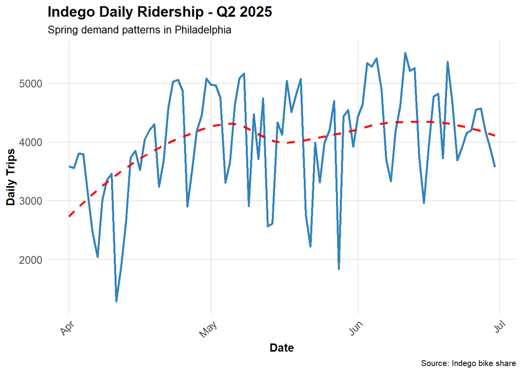

```r
# Daily trip counts
daily_q2_trips <- indego_q2 %>%
  group_by(date) %>%
  summarize(trips = n())

ggplot(daily_q2_trips, aes(x = date, y = trips)) +
  geom_line(color = "#3182bd", linewidth = 1) +
  geom_smooth(se = FALSE, color = "red", linetype = "dashed") +
  labs(
    title = "Indego Daily Ridership - Q2 2025",
    subtitle = "Spring demand patterns in Philadelphia",
    x = "Date",
    y = "Daily Trips",
    caption = "Source: Indego bike share"
  ) +
  plotTheme
```

## Hourly Patterns

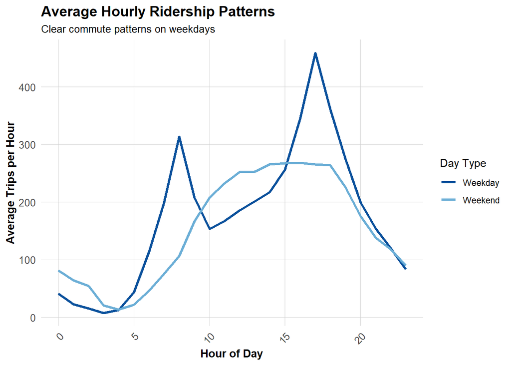

```r
# Average trips by hour and day type
hourly_q2_patterns <- indego_q2 %>%
  group_by(hour, weekend) %>%
  summarize(avg_trips = n() / n_distinct(date)) %>%
  mutate(day_type = ifelse(weekend == 1, "Weekend", "Weekday"))

ggplot(hourly_q2_patterns, aes(x = hour, y = avg_trips, color = day_type)) +
  geom_line(linewidth = 1.2) +
  scale_color_manual(values = c("Weekday" = "#08519c", "Weekend" = "#6baed6")) +
  labs(
    title = "Average Hourly Ridership Patterns",
    subtitle = "Clear commute patterns on weekdays",
    x = "Hour of Day",
    y = "Average Trips per Hour",
    color = "Day Type"
  ) +
  plotTheme
```

## Top Stations

```r
# Most popular origin stations
top_q2_stations <- indego_q2 %>%
  count(start_station, start_lat, start_lon, name = "trips") %>%
  arrange(desc(trips)) %>%
  head(20)

kable(
  top_q2_stations,
  caption = "Top 20 Indego Stations by Trip Origins",
  format.args = list(big.mark = ",")
) %>%
  kable_styling(bootstrap_options = c("striped", "hover"))
```

Top 20 Indego Stations by Trip Origins

| start_station | start_lat | start_lon | trips |
| --- | --- | --- | --- |
| 3,010 | 39.94711 | -75.16618 | 6,278 |
| 3,032 | 39.94527 | -75.17971 | 4,751 |
| 3,359 | 39.94888 | -75.16978 | 4,181 |
| 3,028 | 39.94061 | -75.14958 | 4,028 |
| 3,163 | 39.94974 | -75.18097 | 4,000 |
| 3,020 | 39.94855 | -75.19007 | 3,946 |
| 3,185 | 39.95169 | -75.15888 | 3,914 |
| 3,066 | 39.94561 | -75.17348 | 3,899 |
| 3,022 | 39.95472 | -75.18323 | 3,856 |
| 3,054 | 39.96250 | -75.17420 | 3,767 |
| 3,161 | 39.95486 | -75.18091 | 3,629 |
| 3,362 | 39.94816 | -75.16226 | 3,552 |
| 3,063 | 39.94633 | -75.16980 | 3,516 |
| 3,213 | 39.93887 | -75.16663 | 3,332 |
| 3,059 | 39.96244 | -75.16121 | 3,320 |
| 3,012 | 39.94218 | -75.17747 | 3,264 |
| 3,007 | 39.94517 | -75.15993 | 3,242 |
| 3,061 | 39.95425 | -75.17761 | 3,193 |
| 3,101 | 39.94295 | -75.15955 | 3,170 |
| 3,296 | 39.95134 | -75.16758 | 3,088 |

# PUT DATA IN CONTEXT

## Load Philadelphia Census Data

## Map Philadelphia Context

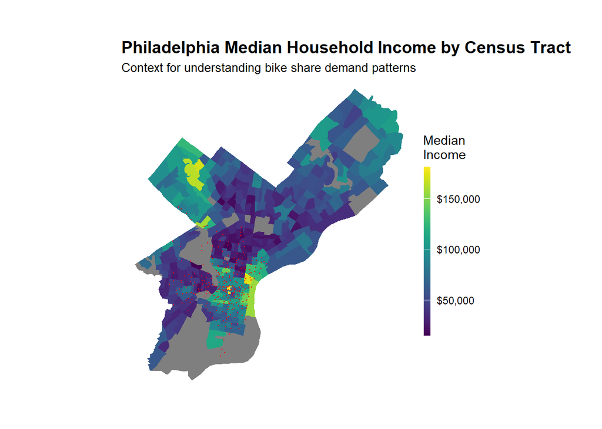

```r
ggplot() +
  geom_sf(data = philly_census_q2, aes(fill = Med_Inc), color = NA) +
  scale_fill_viridis(
    option = "viridis",
    name = "Median\nIncome",
    labels = scales::dollar
  ) +
  labs(
    title = "Philadelphia Median Household Income by Census Tract",
    subtitle = "Context for understanding bike share demand patterns"
  ) +
  geom_point(
    data = indego_q2,
    aes(x = start_lon, y = start_lat),
    color = "red", size = 0.25, alpha = 0.6
  ) +
  mapTheme
```

## Join Census Data to Stations

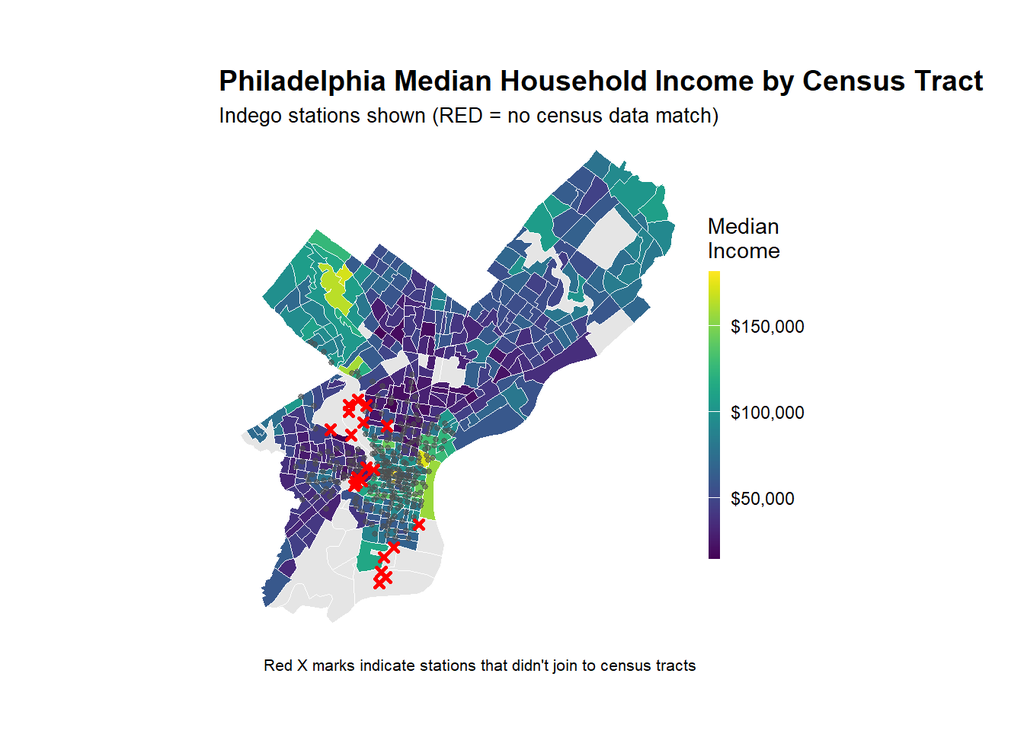

## Dealing with missing data

## Visualize Weather Patterns

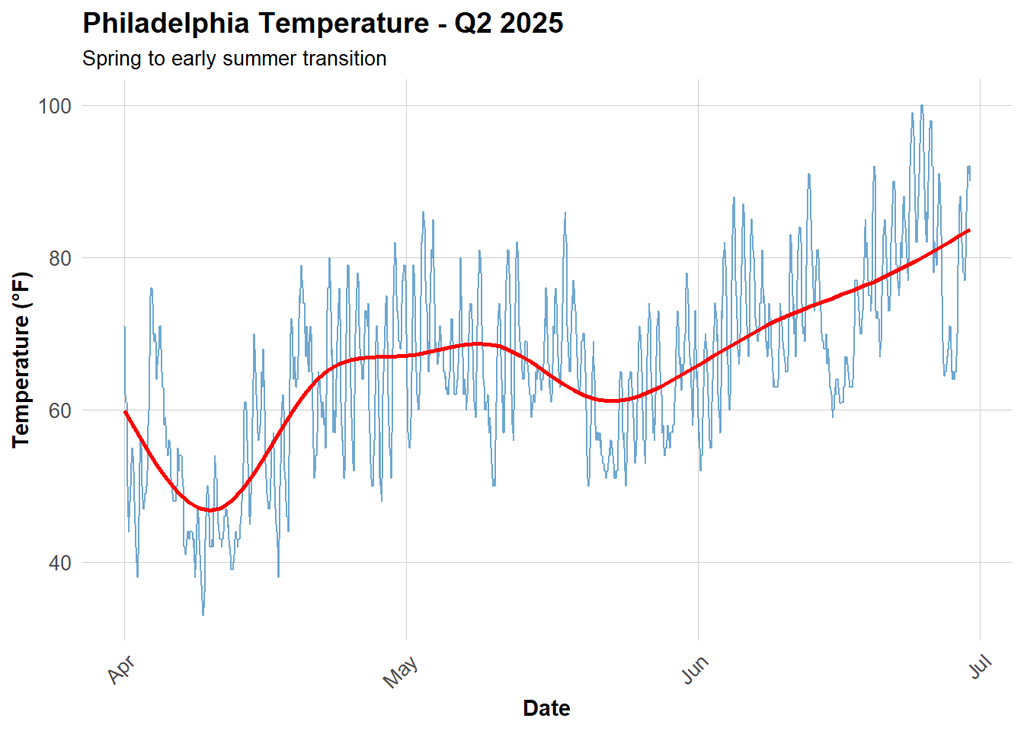

```r
ggplot(weather_complete_q2, aes(x = interval60, y = Temperature)) +
  geom_line(color = "#3182bd", alpha = 0.7) +
  geom_smooth(se = FALSE, color = "red") +
  labs(
    title = "Philadelphia Temperature - Q2 2025",
    subtitle = "Spring to early summer transition",
    x = "Date",
    y = "Temperature (°F)"
  ) +
  plotTheme
```

# CREATE SPACE-TIME PANEL

## Aggregate Trips to Station-Hour Level

```
[1] 179107
```

```
[1] 252
```

```
[1] 2177
```

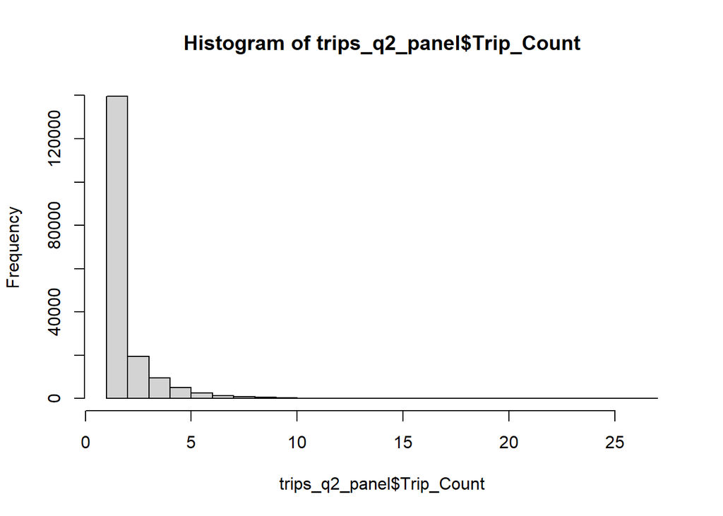

## Create Complete Panel Structure

```
Expected panel rows: 548,604
```

```
Current rows: 179,107
```

```
Missing rows: 369,497
```

```
Rows: 548,604
Columns: 3
$ interval60    <dttm> 2025-04-01, 2025-04-01, 2025-04-01, 2025-04-01, 2025-04…
$ start_station <dbl> 3022, 3040, 3054, 3280, 3301, 3396, 3158, 3371, 3374, 30…
$ Trip_Count    <int> 1, 1, 1, 1, 1, 1, 0, 0, 0, 0, 0, 0, 0, 0, 0, 0, 0, 0, 0,…
```

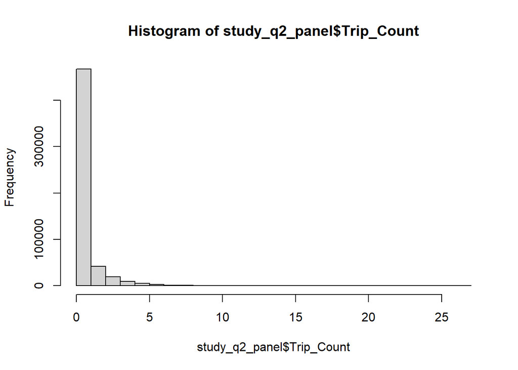

```
Rows: 252
Columns: 7
$ start_station          <dbl> 3005, 3006, 3007, 3008, 3009, 3010, 3012, 3014,…
$ start_lat              <dbl> 39.94733, 39.95220, 39.94517, 39.98081, 39.9557…
$ start_lon              <dbl> -75.14403, -75.20311, -75.15993, -75.15067, -75…
$ Med_Inc                <dbl> 144922, 21064, 58557, 22244, 37674, 88583, 1385…
$ Percent_Taking_Transit <dbl> 11.742827, 9.418565, 11.401515, 27.430556, 10.8…
$ Percent_White          <dbl> 86.29640, 46.88109, 62.85341, 39.65227, 60.2169…
$ Total_Pop              <dbl> 3583, 6156, 4598, 5349, 7375, 3134, 3643, 3914,…
```

```
Rows: 548,604
Columns: 9
$ interval60             <dttm> 2025-04-01, 2025-04-01, 2025-04-01, 2025-04-01…
$ start_station          <dbl> 3022, 3040, 3054, 3280, 3301, 3396, 3158, 3371,…
$ Trip_Count             <int> 1, 1, 1, 1, 1, 1, 0, 0, 0, 0, 0, 0, 0, 0, 0, 0,…
$ start_lat              <dbl> 39.95472, 39.96289, 39.96250, 39.93968, 39.9502…
$ start_lon              <dbl> -75.18323, -75.16606, -75.17420, -75.21362, -75…
$ Med_Inc                <dbl> 29464, 79694, 88936, 39547, 86809, 49493, 61583…
$ Percent_Taking_Transit <dbl> 5.081301, 14.574899, 11.852149, 25.837629, 25.9…
$ Percent_White          <dbl> 54.396043, 61.073826, 60.379375, 9.203540, 79.6…
$ Total_Pop              <dbl> 6267, 2235, 3743, 3955, 1807, 3742, 4029, 3486,…
```

```
Complete panel rows: 548,604
```

# CREATE TEMPORAL LAG VARIABLES

## Visualize Lag Correlations

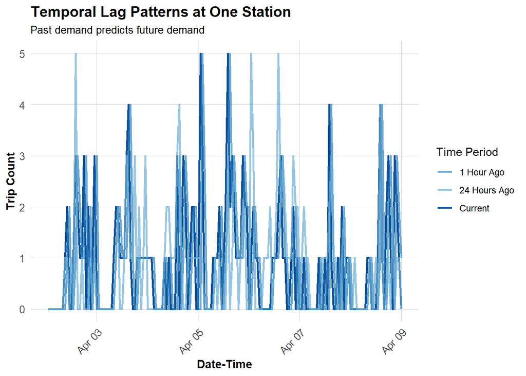

```
Training observations: 374,745
```

```
Testing observations: 161,352
```

```
Training date range: 20180 to 20242
```

```
Testing date range: 20243 to 20269
```

## Model 1: Baseline (Time + Weather)

## Model 2: Add Temporal Lags

## Model 3: Add Demographics

## Model 4: Add Station Fixed Effects

## Model 5: Add Rush Hour Interaction

# MODEL EVALUATION

## Calculate Predictions and MAE

Mean Absolute Error by Model (Test Set, Q2 2025)

| Model | MAE (trips) |
| --- | --- |
| 1. Time + Weather | 0.84 |
| 2. + Temporal Lags | 0.69 |
| 3. + Demographics | 0.69 |
| 4. + Station FE | 0.69 |
| 5. + Rush Hour Interaction | 0.71 |

## Visualize Model Comparison

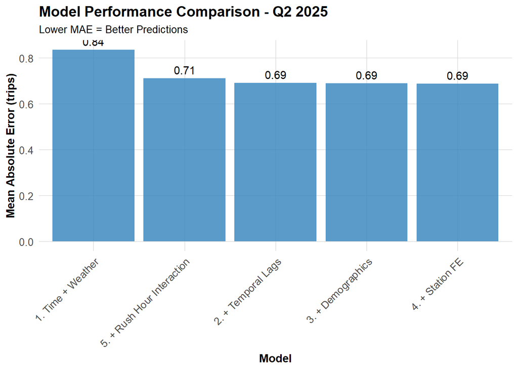

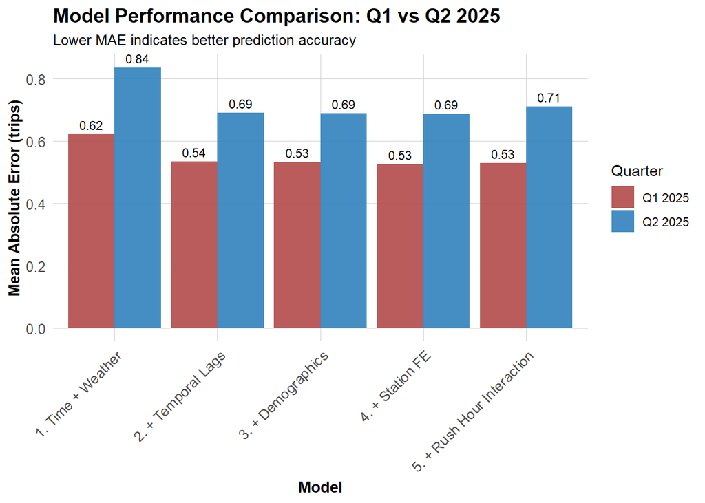

## Daily trips comparison

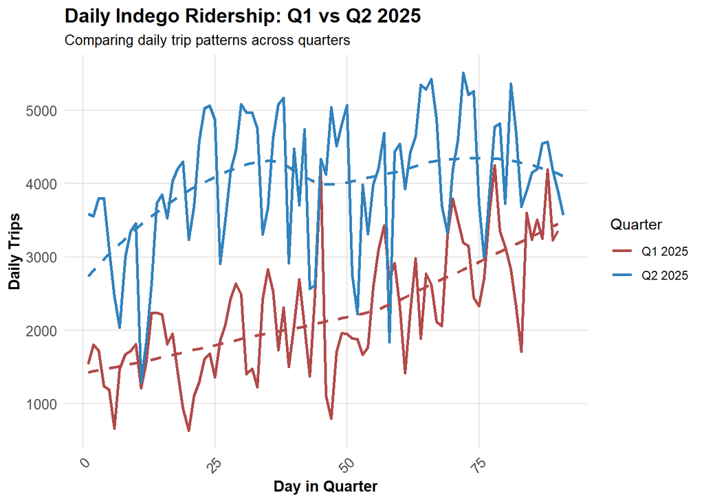

## Hourly pattern comparison

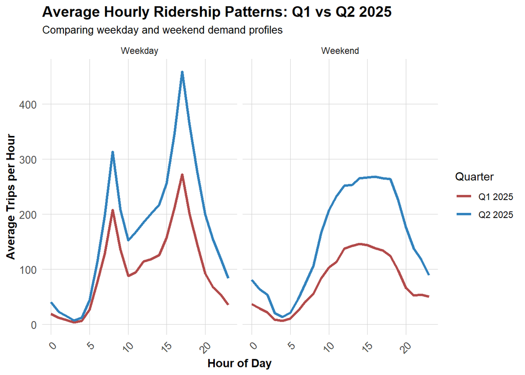

```
-   How do MAE values compare? Why might they differ?
-   Are temporal patterns different (e.g., summer vs. winter)?
-   Which features are most important in your quarter?
```

MAE values are consistently higher in Q2 2025 than in Q1 2025. One likely reason is that overall bike-share demand is higher in Q2, so prediction errors measured in absolute trip counts also become larger. In addition, Q2 covers April to June, when warmer and more variable weather may lead to more complex travel behavior. Compared with the colder and more commute-driven patterns in Q1, Q2 likely includes more discretionary and weather-sensitive trips, which makes demand harder to predict and increases model error.

Q1 and Q2 show similar hourly structures: weekday demand peaks during the morning and evening commute periods, while weekend demand stays elevated from mid-day to early evening. However, the daily ridership comparison suggests a clearer difference across quarters. In Q1, daily trips generally increase over time, while Q2 shows a more fluctuating pattern, with alternating periods of increase and decline. A likely explanation is seasonal weather variation. Bike-share demand may be lower when temperatures are either too cold or too hot, and Q2 appears to be more sensitive to these changes. In particular, the drop in temperature during May may be associated with the first decline in trips, while the sustained temperature increase in June may help explain the second decline.

The most important features in my quarter are the temporal lag variables. This is clear from the large drop in MAE from Model 1 to Model 2, after adding lag1Hour, lag3Hours, and lag1day. This suggests that recent station demand is the strongest predictor of future demand in Q2 2025.

## Part 2: Error Analysis

Analyze your model’s errors in detail:

1. **Spatial patterns:**
   - Create error maps
   - Identify neighborhoods with high errors
   - Hypothesize why (missing features? different demand patterns?)
2. **Temporal patterns:**
   - When are errors highest?
   - Do certain hours/days have systematic under/over-prediction?
   - Are there seasonal patterns?
3. **Demographic patterns:**
   - Relate errors to census characteristics
   - Are certain communities systematically harder to predict?
   - What are the equity implications?

# SPACE-TIME ERROR ANALYSIS

## Observed vs. Predicted

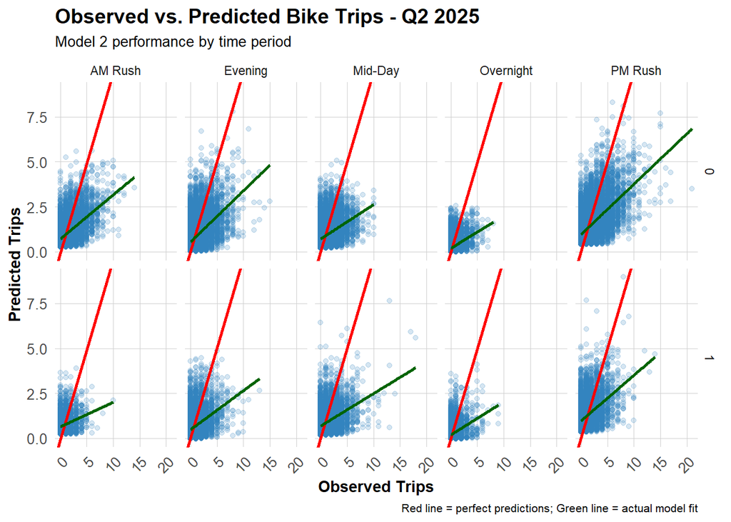

## Spatial Error Patterns

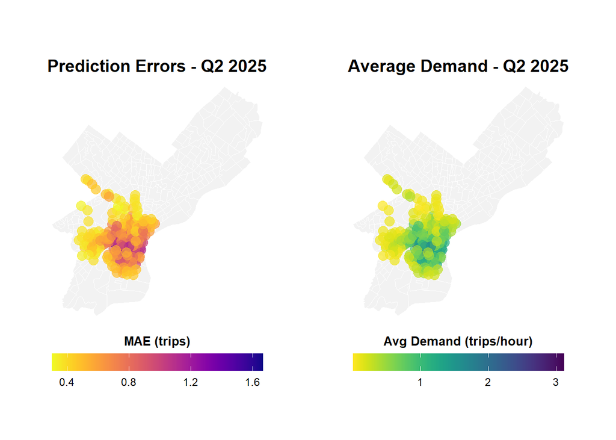

## Temporal Error Patterns

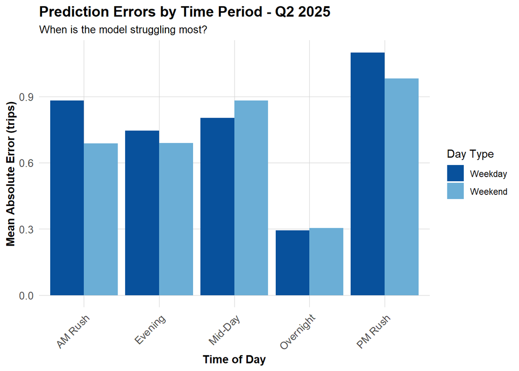

## Errors and Demographics

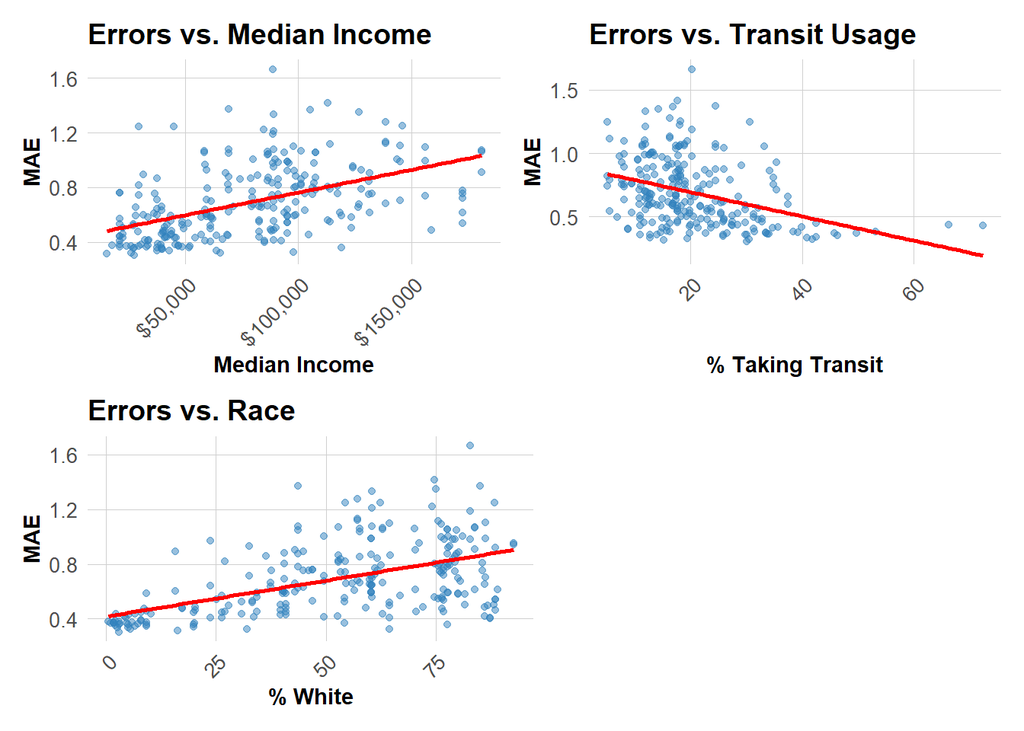

Spatial patterns errors are concentrated in the central part of Philadelphia, where demand is also highest. This suggests that the model struggles most at the busiest stations. A likely reason is that these central stations have more complex demand patterns, including commuting, which are not fully captured by the current model.

Temporal patterns errors are highest during PM Rush, and they are also relatively high during AM Rush and Mid-Day, while overnight errors are lowest. This means the model performs worst when demand is high and changes quickly. The observed-versus-predicted plots also suggest some under-prediction at peak demand levels. Q2 likely has stronger seasonal and weather-related variation, which may further increase daytime prediction error.

Demographic prediction errors are associated with neighborhood characteristics. Errors tend to increase with median income and % White, and decrease as transit usage increases. This suggests that some communities may be systematically harder to predict, but these should be interpreted as associations rather than causal effects. The equity concern is that if errors are concentrated in certain communities, forecast-based service decisions may also become uneven.

## Part 3: Feature Engineering & model improvement

MAE Comparison: Baseline vs. Feature-Engineered Model (Q2 2025)

| Model | MAE |
| --- | --- |
| Model 2 Baseline | 0.690 |
| Model 6 + New Features | 0.673 |

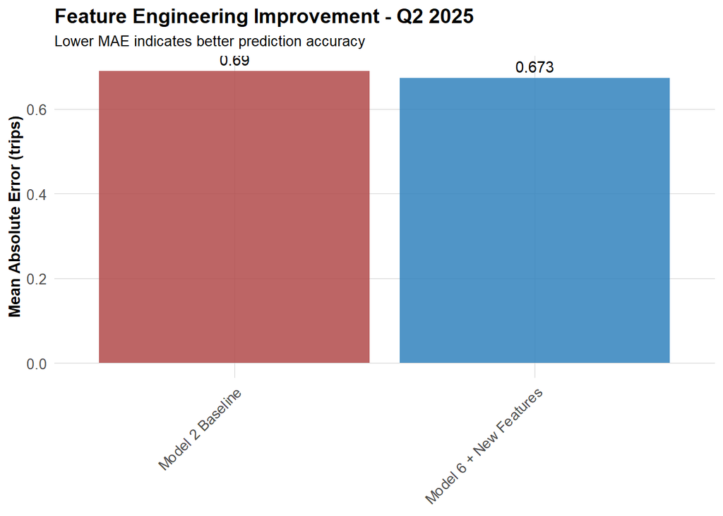

MAE Comparison: Baseline, Linear FE Model, and Poisson FE Model (Q2 2025)

| Model | MAE |
| --- | --- |
| Model 2 Baseline | 0.690 |
| Model 6 Linear | 0.673 |
| Model 6 Poisson | 0.692 |

In this part, I added three new features to Model 2: same_hour_last_week_q2, dist_center_city_q2, and perfect_weather_q2. After adding these variables, the test-set MAE decreased from 0.690 to 0.673, which indicates a small improvement in predictive accuracy.

I chose same_hour_last_week_q2 because the model showed larger errors during peak periods, and demand at the same hour in the previous week may help capture recurring temporal patterns. I added dist_center_city_q2 because the spatial error maps suggested that both higher errors and higher demand were concentrated in the central city, so distance to Center City may help explain this spatial variation. I also added perfect_weather_q2 because ridership in Q2 appeared to be more sensitive to seasonal and weather conditions, with demand patterns moving together with changes in temperature.

These features improved model performance, but only slightly. Among them, same_hour_last_week_q2 and dist_center_city_q2 were more useful, while perfect_weather_q2 had a weaker effect. This suggests that the model is still missing other important factors, such as holidays and other contextual influences that affect ridership. In addition, the Poisson model did not improve performance and actually performed worse than Model 6.

## Part 4: Critical Reflection

Write 1-2 paragraphs addressing:

1. **Operational implications:**
   - Is your final MAE “good enough” for Indego to use?
   - When do prediction errors cause problems for rebalancing?
   - Would you recommend deploying this system? Under what conditions?
2. **Equity considerations:**
   - Do prediction errors disproportionately affect certain neighborhoods?
   - Could this system worsen existing disparities in bike access?
   - What safeguards would you recommend?
3. **Model limitations:**
   - What patterns is your model missing?
   - What assumptions might not hold in real deployment?
   - How would you improve this with more time/data?

My final model is useful, but it is not accurate enough to support fully automated rebalancing on its own. An MAE of about 0.673 suggests that it can help Indego identify overall demand patterns, but prediction errors would still create operational problems when they occur at high-demand stations or during peak hours. For that reason, this model is better understood as an initial decision-support tool rather than a replacement for human rebalancing decisions.